# Subscriptions Report

Kevin Yan

2017-08-27

## Abstract

In this report we’re going to be looking to see if there are any visible factors in the data that contribute to higher subscriptions rates and counts. We will look at the data to see if there are any noticable patterns starting at the user level, all the way up to the school level.

## Methodology

Ultimately the goal is to understand what factors affect the amount of subscriptions to the service. In order to do so, we must first genearte response variables that can measure the intended targets, thus in the analysis I will proceed to use `Subscription Rate`, as well `Subscription Counts` to represent the targets. Because we have decided to break down the analysis into different view points based on the hierarchy of the school system, we need to generate these values through aggregation.

We first look at students to see if there are differences in their attributes or behaviour that can explain their likelihood of subscribing. We will then consider if there are differences in courses that can explain why some courses may be more successful in inducing subscribers. We continue this type of analysis for departments, and finally to the schools themselves. However, we do notice that there is limited additional information we get at the different levels (ie: courses, departments, schools), any significant contributors we find at the more specific levels should translate to the higher levels. This is a prediction solely based on the fact that columns like `enrollment count`, `documents count`, and `subscription` at higher levels are aggregated from those same counts from lower levels.

## Analysis and Results

### Users

#### Overview

Below you will see a preview of the variables we will be using in our analysis, and some of the values that they take on.

```r
str(users_final)
```

```
## 'data.frame':    199951 obs. of  14 variables:
##  $ id               : num  29876 29877 29878 29879 29880 ...
##  $ email            : chr  "iwwyzst@gmail.com" "qdpts@gmail.com" "jcuurpb@gmail.com" "msauf@gmail.com" ...
##  $ status           : chr  "activated" "activated" "activated" "activated" ...
##  $ current_balance  : num  2813 4805 3597 3891 3047 ...
##  $ created_at       : POSIXct, format: "2017-08-16 17:13:31" "2017-08-16 17:13:31" ...
##  $ name             : chr  "QN" "ZY" "XDQ" "TEDY" ...
##  $ school_id        : Factor w/ 10 levels "1","2","3","4",..: 1 1 1 1 1 1 1 1 1 1 ...
##  $ enrollments_count: num  0 1 1 0 0 0 0 0 0 0 ...
##  $ votes_count      : num  0 0 0 0 0 0 0 0 0 0 ...
##  $ sign_in_count    : num  12 5 0 10 10 9 4 17 8 6 ...
##  $ country_id       : Factor w/ 3 levels "1","2","3": 1 1 1 1 1 1 1 1 1 1 ...
##  $ documents_count  : num  0 1 1 0 0 0 0 0 0 0 ...
##  $ kind             : chr  NA NA NA NA ...
##  $ has_subscription : logi  FALSE FALSE FALSE FALSE FALSE FALSE ...
```

For the most part, we will only be looking at variables with numerical values, with the one exclusion being `school_id`. Many of the other variables are used to identify the user, and I have excluded them for further analysis. In addtion `status` is constant for all users, and hence doesn’t add variation to the data.

Because our target variable `has_subscription` is a boolean, we can perform a logistic regression on all the other variables to see if they have any meaningful contribution to the the probability of subscription. We’ve decided to use logistic regression both because we are dealing with a classification problem, and because we will be able to interpret the model parameters after fitting the model.

We used `AIC` as a metric for model selection, and after trying a lot of different variations of the data variables, the best, and most minimalistic model based on AIC strictly only contained the school variable.

```r
summary(users_final_model)
```

```
##
## Call:
## glm(formula = has_subscription ~ school_id, family = binomial(),
##     data = users_final)
##
## Deviance Residuals:
##     Min       1Q   Median       3Q      Max
## -0.2644  -0.2195  -0.1946  -0.1382   3.7169
##
## Coefficients:
##             Estimate Std. Error z value Pr(>|z|)
## (Intercept) -3.49862    0.04189 -83.512  < 2e-16 ***
## school_id2   0.16258    0.05712   2.846 0.004422 **
## school_id3  -0.21521    0.06251  -3.443 0.000576 ***
## school_id4  -0.45876    0.06688  -6.860 6.91e-12 ***
## school_id5  -3.40803    0.22759 -14.975  < 2e-16 ***
## school_id6  -0.99997    0.07969 -12.548  < 2e-16 ***
## school_id7  -0.34572    0.06475  -5.339 9.34e-08 ***
## school_id8  -1.90019    0.11365 -16.720  < 2e-16 ***
## school_id9  -0.42361    0.06621  -6.398 1.57e-10 ***
## school_id10 -1.14784    0.08408 -13.652  < 2e-16 ***
## ---
## Signif. codes:  0 '***' 0.001 '**' 0.01 '*' 0.05 '.' 0.1 ' ' 1
##
## (Dispersion parameter for binomial family taken to be 1)
##
##     Null deviance: 34868  on 199950  degrees of freedom
## Residual deviance: 33439  on 199941  degrees of freedom
## AIC: 33459
##
## Number of Fisher Scoring iterations: 9
```

#### Interpretation

From the model we can see that the significant variables appear to be those coming from the school, meaning that the institution that the user is from plays a significant role in their likelihood of subscribing to the service. In logistic regression, the response that’s being modelled is actually the `log(odds)` of a user having a subscription/being subscribed. We define odds as the ratio: `P(success)/P(failure)`. So using this definition, if a student is from **School 1**, they would have about a `2.9%` chance of being a subscriber. **School 2** is the only institution where the students are more likely to be subscribers than the base school. From this we can infer that there may some differences in schools that may account for increased subscription rates, and we could possibly look at school 2 for such indications.

[interactive chart not shown]

### Courses

We’ve decided to skip over the analysis at the `course` level because courses and department data frames both contain very similar numeric variables, where the latter are just aggregation of the former. In addition, I was unable to find any meaningful correlation between many of the numeric variables at the course level as exhibited below. The only predictor variables in the bunch would be `doc counts` and `enrollment_count`.

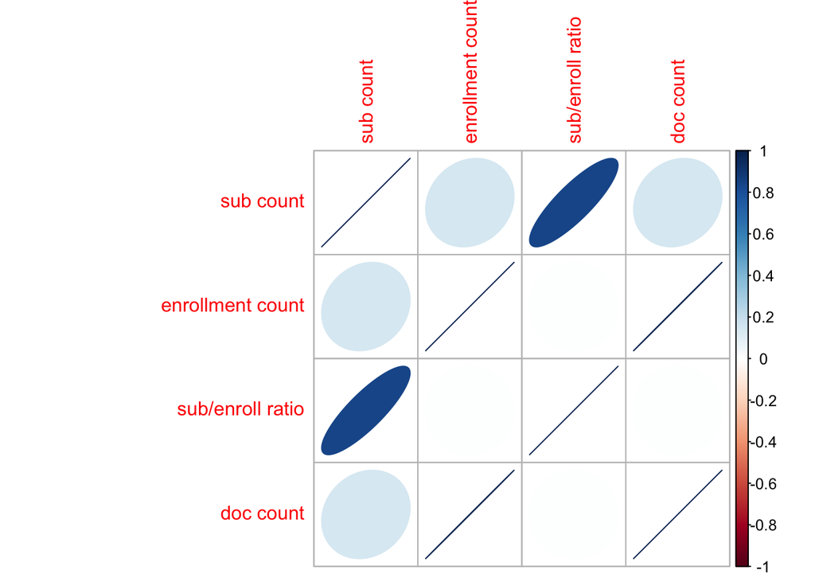

```r
corrplot(ce_corr_matrix, method="ellipse")
```

If you observe the sub count column, we see that it’s not strongly related to any of the variables except for `sub/enroll ratio`, however that should be disregarded because they’re both proxies for our target of interest, and one is used in the creation of the other.

### Departments

#### Overview

We’ll now try to look at this problem at the department level. The variables that we will look at in this part of the analysis will be shown below:

```
## Classes 'tbl_df', 'tbl' and 'data.frame':    1316 obs. of  6 variables:
##  $ id               : num  682 683 696 706 715 725 726 732 758 764 ...
##  $ school_id        : Factor w/ 10 levels "1","2","3","4",..: 3 3 3 3 3 2 2 2 1 1 ...
##  $ total_subs       : int  1 2 1 1 1 1 1 1 2 2 ...
##  $ total_enrollments: int  6 6 3 29 6 4 8 3 15 11 ...
##  $ num_docs_dep     : int  5 5 2 28 5 3 7 2 14 10 ...
##  $ num_courses      : int  2 2 1 12 1 2 2 1 12 10 ...
```

We are now going to use `total_subs` as our target variable in this part of the analysis, thus we want to see what factors can contribute to changes in this particular variable. Many of these are numeric values, except for of course `school_id`. Because we have so many numeric values, we can generate a correlation matrix and plot to see if we can detect any relationships in the data.

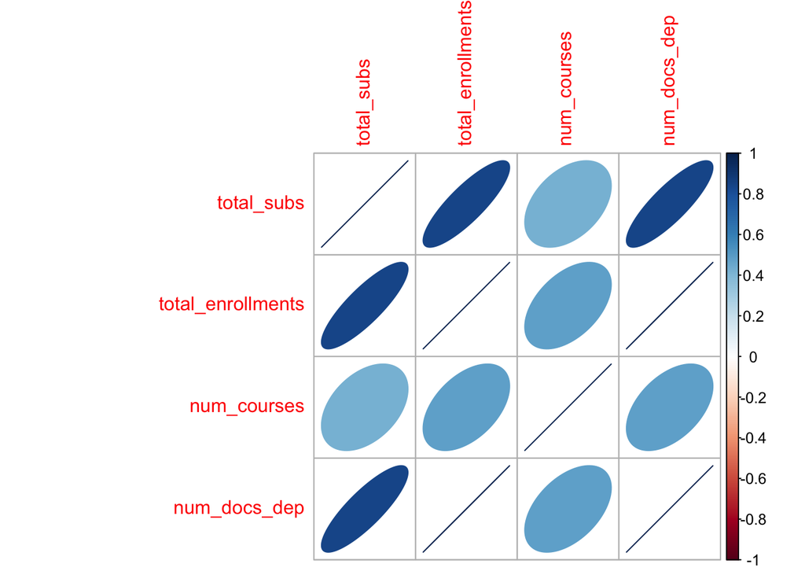

1. number of enrollments in the department
2. number of coursesin the department
3. number of documents in the department

We can try to better quantify and understand these relationships by fitting a model. The model I will choose will be another `Generalized Linear Model`; In order to model counts(ie: total subs), we will be using `Poisson Regression`.

We used the `step` function in the `stats` package in order to compare multiple models, using different variations of the available variables, and the best model is presented below:

```
##
## Call:
## glm(formula = total_subs ~ school_id + num_docs_dep, family = poisson(),
##     data = full_dep)
##
## Deviance Residuals:
##     Min       1Q   Median       3Q      Max
## -3.3313  -0.1637  -0.0123   0.0007   2.6231
##
## Coefficients:
##                Estimate Std. Error z value Pr(>|z|)
## (Intercept)   0.4944964  0.0650710   7.599 2.98e-14 ***
## school_id2    0.1207949  0.1009259   1.197 0.231358
## school_id3   -0.1487060  0.1028535  -1.446 0.148232
## school_id4   -0.4822422  0.0868958  -5.550 2.86e-08 ***
## school_id5   -0.4952324  0.0987834  -5.013 5.35e-07 ***
## school_id6   -0.4975237  0.0939421  -5.296 1.18e-07 ***
## school_id7   -0.2868242  0.0862615  -3.325 0.000884 ***
## school_id8   -0.5149234  0.1125774  -4.574 4.79e-06 ***
## school_id9   -0.1427319  0.0948630  -1.505 0.132424
## school_id10  -2.4631415  0.4761227  -5.173 2.30e-07 ***
## num_docs_dep  0.0066261  0.0003039  21.803  < 2e-16 ***
## ---
## Signif. codes:  0 '***' 0.001 '**' 0.01 '*' 0.05 '.' 0.1 ' ' 1
##
## (Dispersion parameter for poisson family taken to be 1)
##
##     Null deviance: 990.74  on 1315  degrees of freedom
## Residual deviance: 237.13  on 1305  degrees of freedom
## AIC: 3149.8
##
## Number of Fisher Scoring iterations: 4
```

The model recognizes that the `school` the department belongs to, and the `number of documents` the department has under its name on the platform contribute the most to the number of subscriptions. In order to interpret the coefficients presented, we must exponentiate them, because `Poisson Regression` estimates the `log(counts)`.

```r
exp(coef(new_dep_model))
```

```
##  (Intercept)   school_id2   school_id3   school_id4   school_id5
##   1.63967229   1.12839347   0.86182241   0.61739750   0.60942924
##   school_id6   school_id7   school_id8   school_id9  school_id10
##   0.60803448   0.75064371   0.59754637   0.86698649   0.08516697
## num_docs_dep
##   1.00664808
```

### Schools

In the previous sections were able to see the importance the school variable played in the analysis. Thus we should definitely try to uncover the reason behind the enigmas we’ve uncovered in previous sections. Like every section before, we will start off with a preview of the variables we will be looking at:

```
## 'data.frame':    40 obs. of  17 variables:
##  $ id                  : Factor w/ 10 levels "1","2","3","4",..: 1 1 1 1 2 2 2 2 3 3 ...
##  $ name                : chr  "School-A" "School-A" "School-A" "School-A" ...
##  $ country_id          : Factor w/ 3 levels "1","2","3": 1 1 1 1 1 1 1 1 1 1 ...
##  $ country             : chr  "ca" "ca" "ca" "ca" ...
##  $ courses_count       : int  2922 2922 2922 2922 1793 1793 1793 1793 1687 1687 ...
##  $ departments_count   : int  118 118 118 118 47 47 47 47 64 64 ...
##  $ has_doc_ratio       : num  0.741 0.741 0.741 0.741 0.945 ...
##  $ num_course_with_docs: int  2164 2164 2164 2164 1694 1694 1694 1694 1573 1573 ...
##  $ doc_1               : int  1266 1266 1266 1266 1662 1662 1662 1662 1529 1529 ...
##  $ doc_2               : int  1356 1356 1356 1356 1706 1706 1706 1706 1517 1517 ...
##  $ doc_3               : int  1378 1378 1378 1378 1632 1632 1632 1632 1454 1454 ...
##  $ total_docs          : int  4000 4000 4000 4000 5000 5000 5000 5000 4500 4500 ...
##  $ num_of_enrollments  : int  4000 4000 4000 4000 5000 5000 5000 5000 4500 4500 ...
##  $ kind                : chr  "monthly" "quarterly" "yearly" "total_subs" ...
##  $ subscriptions       : num  122 115 350 587 138 129 420 687 97 84 ...
##  $ total_students      : num  19999 19999 19999 19999 19997 ...
##  $ subscription_ratio  : num  0.0061 0.00575 0.0175 0.02935 0.0069 ...
```

The target variables we have this time around are `subscriptions` (which counts the number of users subscribed from this school), and `subscription_ratio` (subscribers/students). Thus when we view the correlation matrix, we should focus on those particular rows (or columns, because of symmetry).

[interactive chart not shown]

We can see that because `subscription ratio` and `subscriptions` are so similar, we see that the correlations between these and the other variables appear very similar. It appears as though the number of documents, of all types has a positive linear relationship with `subscriptions`. Moreover, we see that `has_doc_ratio` (which is a measurement of the proportion of courses with documents) has a positive relationship with `subscriptions`. It’s a bit suprising, but in line with what we’ve just talked about that course and department counts have slight negative associations with `subscriptions`. I think this could be because people don’t like seeing blank/missing content, or perhaps their hopes were high when they saw the course code, but disappointed when there’s little or no content associated with them. In addition, increased enrollment also seems to be linked to higher levels of `subscriptions`.

Something that’s also interesting is that values for these variables have relatively the same proportions as we cycle through schools. We can see for example that `school 2` always has one of the higher values for all the variables of interest, while `school 5 and 8` are generally on the lower end. This seems to emphasize that the relationship that was brought to light in the correlation matrix above.

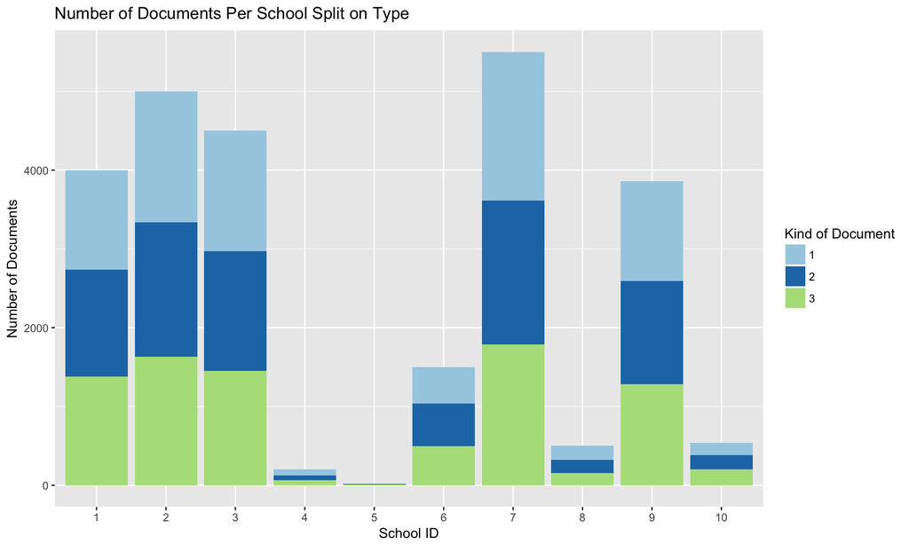

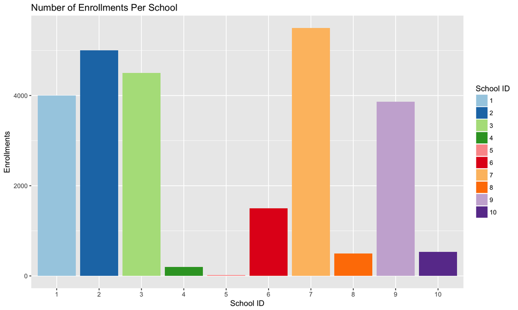

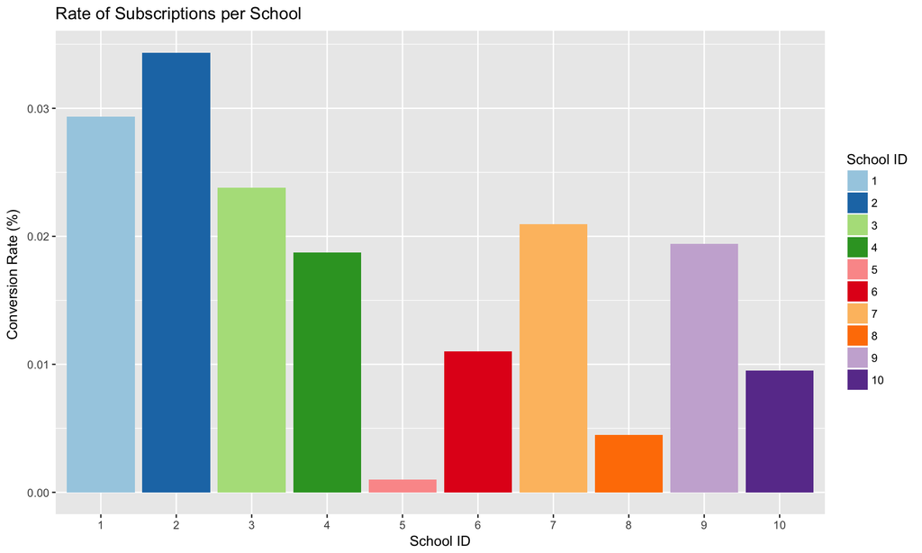

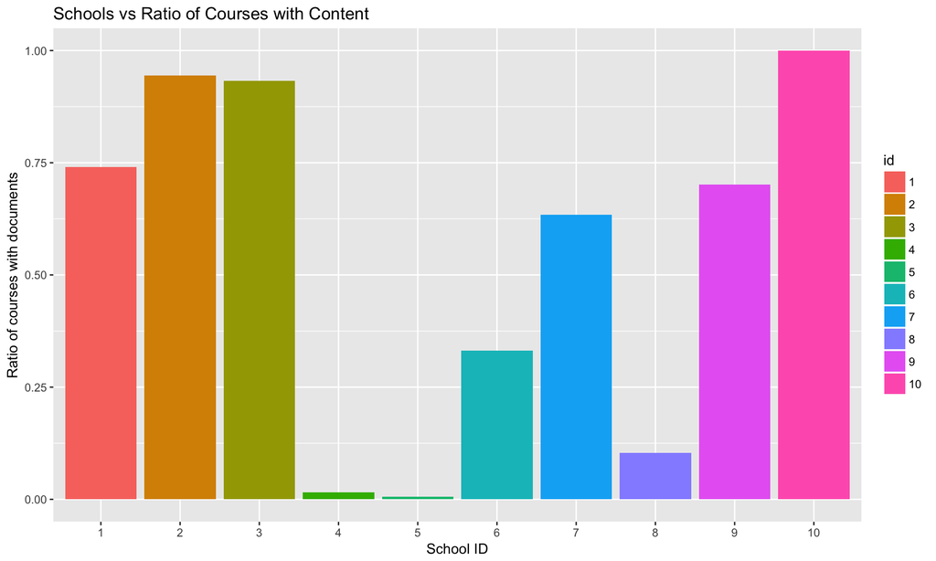

## Conclusions and Suggestions

Throughout the entire analysis we have seen that the school the users are from have a big impact on the number of subscriptions that come as a result. Finally looking at the school level, we see that the number of documents, of all sorts have a positive impact on subscriptions. Thus increasing documents should be a priority if the goal is to gain subscribers. Moreover, the amount of people enrolled in the schools and departments are also related to subscriptions, although the strategy around this relationship may not be as clear as increasing the number of documents. Finally we saw that the number of courses, and departmentsdon’t actually play a huge factor in the bumping subscriber counts, however having more courses with documents helps, as seen by the `has_doc_ratio` variable in the correlation matrix in the previous section.